# An In-depth Analysis of BMI Distribution Trends and Influencing Factors in Scotland from 2008 to 2012

# 1 Introduction

The Body Mass Index (BMI) serves as a fundamental metric in assessing the balance between an individual’s height and weight, offering a critical window into public health. This project embarks on a statistical journey to dissect the distribution and determinants of BMI across Scotland over a five-year period, from 2008 to 2012. Utilizing data from the Scottish Health Surveys, we aim to uncover the trends and fluctuations in BMI and delve into how various socio-economic and lifestyle factors, such as age, gender, employment status, and daily consumption of fruits and vegetables, interplay in shaping these patterns.

Section 2 explores the BMI data from the Scottish Health Surveys, focusing on how BMI varies by age, gender, employment, and diet as well as looking at how BMI has changed over the length of the study. We’ll look for trends and differences across these groups. Section 3 breaks down the results from a regression model that predicts BMI based on these factors and checks if our model holds up statistically. The final remarks, where we wrap up our findings and talk about their impact, are in Section 4.

# 2 Exploratory Analysis

Table 1 displays the summary statistics for BMI by year. We can see that both the mean and median BMI is very consistent in each year,with the highest average BMI being in 2010 and the lowest in 2009. The variability given by the standard deviation also very similar in every year.

Table 1: Summary statistics of BMI by Year.

| Year | Mean | sd | Min | Q1 | Median | Q3 | max |
| --- | --- | --- | --- | --- | --- | --- | --- |
| 2012 | 27.83018 | 5.245886 | 14.06332 | 24.21035 | 27.18101 | 30.78594 | 52.20707 |
| 2011 | 27.84090 | 5.361751 | 12.59330 | 24.08850 | 27.11240 | 30.86285 | 58.39904 |
| 2010 | 27.88476 | 5.249226 | 15.11926 | 24.14778 | 27.31126 | 30.95667 | 56.87901 |
| 2009 | 27.72092 | 5.250873 | 14.32244 | 23.97237 | 27.03125 | 30.73777 | 59.11230 |
| 2008 | 27.78569 | 5.164536 | 15.21140 | 24.17638 | 27.23101 | 30.65417 | 56.42805 |

Figure 1 shows the similarity in the distributions of BMI by year.

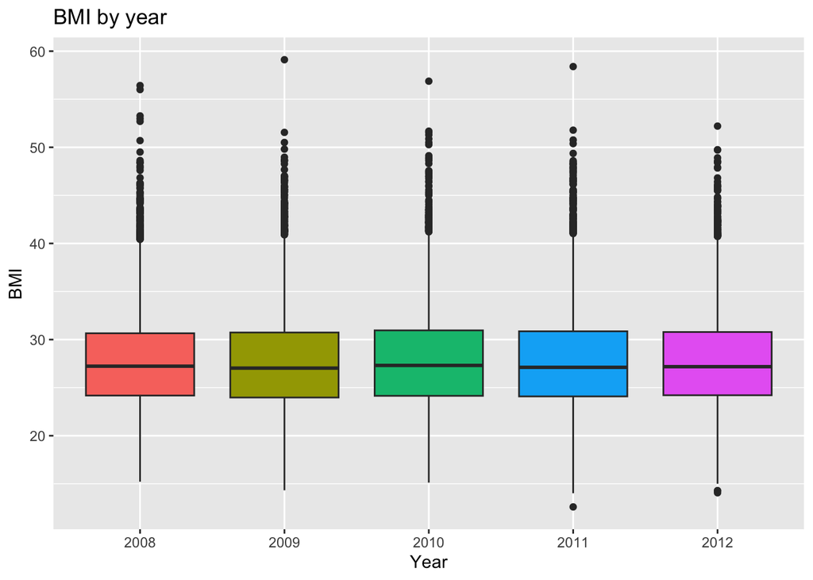

Figure 1: Boxplot of BMI by Year.

From Table 2 we can see that males have slightly higher mean BMI (`27.87`) than females (`27.76`) but this does not appear substantial. We do see that females BMI has higher variability given by a standard deviation of `5.77` compared to only `4.55` for males, indicating that BMI values for females is more spread out than males.

Table 2: Summary statistics of BMI by Sex.

| Sex | Mean | sd | Min | Q1 | Median | Q3 | max |
| --- | --- | --- | --- | --- | --- | --- | --- |
| Male | 27.87044 | 4.54925 | 14.7532 | 24.76155 | 27.53929 | 30.64631 | 48.90603 |
| Female | 27.76289 | 5.76535 | 12.5933 | 23.58510 | 26.80931 | 30.95225 | 59.11230 |

Table 3 displays the summary statistics for different age groups, it shows a consistent median range from the mid to high 20s, suggesting a similar central tendency across the population. Notably, the 16-24 age group has a slightly lower mean BMI, whereas the 65-74 and 55-64 age groups report higher mean values. The standard deviation across all groups indicates a comparable level of variation, with the youngest age group showing the highest spread. The minimum BMI values highlight extreme cases, particularly low 25-34 age groups.

Table 3: Summary statistics of BMI by Age Group.

| AgeGroup | Mean | sd | Min | Q1 | Median | Q3 | max |
| --- | --- | --- | --- | --- | --- | --- | --- |
| 16-24 | 24.91773 | 5.324188 | 14.75320 | 21.23021 | 23.72787 | 27.44041 | 50.38387 |
| 25-34 | 26.55986 | 5.274642 | 12.59330 | 22.81432 | 25.62367 | 29.19692 | 53.27011 |
| 35-44 | 27.94063 | 5.275782 | 14.65770 | 24.12674 | 27.14033 | 30.87546 | 56.00762 |
| 45-54 | 28.24257 | 5.219117 | 14.01423 | 24.55340 | 27.52647 | 31.04864 | 58.39904 |
| 55-64 | 28.76394 | 5.068483 | 14.29159 | 25.22949 | 28.28717 | 31.62694 | 59.11230 |
| 65-74 | 28.65006 | 4.971554 | 14.06332 | 25.20389 | 28.04867 | 31.48570 | 52.98097 |
| 75+ | 27.79826 | 4.736084 | 14.32244 | 24.67539 | 27.47148 | 30.53210 | 47.60416 |

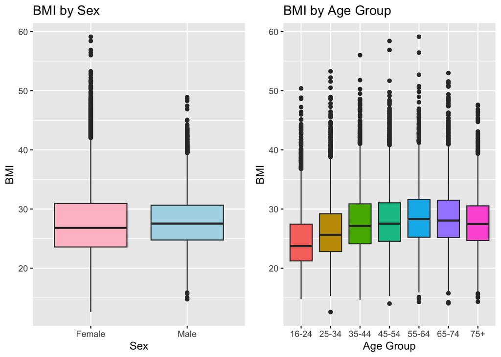

Figure 2: Boxplot of BMI by Sex(left) and by Age Group(right).

Table 4: Summary statistics of BMI by Employment.

| Employment | Mean | sd | Min | Q1 | Median | Q3 | max |
| --- | --- | --- | --- | --- | --- | --- | --- |
| Retired | 28.39995 | 4.989838 | 14.06332 | 25.01532 | 27.88670 | 31.20256 | 59.11230 |
| In paid employment, self-employed or on gov't training | 27.79875 | 5.077836 | 12.59330 | 24.17612 | 27.09391 | 30.67210 | 56.87901 |
| Looking after home/family | 27.47766 | 5.856789 | 15.28982 | 23.19304 | 26.62898 | 30.70962 | 56.00762 |
| Perm unable to work | 28.81225 | 6.479857 | 14.01423 | 24.23315 | 28.30977 | 32.39821 | 52.69819 |
| Looking for/intending to look for paid work | 26.94632 | 6.043188 | 16.23816 | 22.42197 | 25.84544 | 30.51944 | 58.39904 |
| Doing something else | 27.12936 | 4.997645 | 17.70488 | 23.55847 | 26.73442 | 30.41980 | 45.12584 |
| In full-time education | 24.47457 | 4.844623 | 14.75320 | 21.04370 | 23.60400 | 26.84857 | 48.62064 |

Table 5: Summary statistics of BMI by Lifestyle.

| Lifestyle | Mean | sd | Min | Q1 | Median | Q3 | max |
| --- | --- | --- | --- | --- | --- | --- | --- |
| Both | 27.80893 | 5.116673 | 14.01423 | 24.22178 | 27.10957 | 30.66890 | 59.11230 |
| Just Fruit | 28.32466 | 5.415242 | 15.89355 | 24.38119 | 27.68961 | 31.40499 | 58.39904 |
| Just Veg | 27.62551 | 5.289722 | 12.59330 | 23.77604 | 27.16676 | 30.69735 | 53.27011 |
| None | 27.63664 | 5.742472 | 14.06332 | 23.60400 | 27.00254 | 30.93224 | 51.68052 |

Figure 3 shows the BMI distributions by Employment type(left) and by Lifestyle (right) which is categorised into whether the person consumes the daily recommended fruit/veg or both.

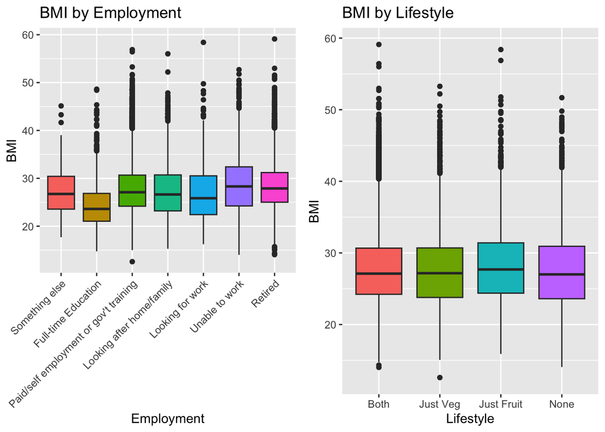

Figure 3: Boxplot of BMI by Employment(left) and Lifestyle(right).

# 3 Formal Analysis

## 3.1 3.1 changes in Body Mass Index (BMI) in Scotland over the years

We start our statistical analysis on the 2008 - 2012 Scottish Health Surveys data set by fitting a linear model of the average BMI against the year to see if there is a significant change of BMI over the given years. Below is the linear model we are fitting:

$$\begin{aligned}
y_{i} &= \alpha + \beta_1 \cdot x_{1i} + \beta_2 \cdot x_{2i} + \beta_3 \cdot x_{3i} + \beta_4 \cdot x_{4i} + \epsilon_i, ~~~~ \epsilon_i \sim N(0, \sigma^2), ~~~~ i=1,\ldots,25224 \nonumber \\
&= \alpha + \beta_{\mbox{2009}} \cdot \mathbb{I}_{\mbox{2009}}(x) + \beta_{\mbox{2010}} \cdot \mathbb{I}_{\mbox{2010}}(x) + \beta_{\mbox{2011}} \cdot \mathbb{I}_{\mbox{2011}}(x) +
\beta_{\mbox{2012}} \cdot \mathbb{I}_{\mbox{2012}}(x) +
\epsilon_i, \nonumber
\end{aligned}$$

Prior to examining the regression results, we defined our null hypothesis (H0) as there being no significant change in the average BMI in Scotland from 2008 to 2012, and the alternative hypothesis (H1) as there being a significant change in average BMI during the same period.

This model obtains the following regression table; Table 6. Here we can see that all the $\beta_{\mbox{year}}$ p values are greater than 0.05, our chosen significance level. This suggest that all $\beta_{\mbox{year}}$ terms are not significant and we fail to reject the null hypothesis that the average BMI in Scotland has not changed over the given years. Thus we should fit the null model, that is the model with an intercept term only

Table 6: Estimates of the regression model coefficients.

| term | estimate | std_error | statistic | p_value | lower_ci | upper_ci |
| --- | --- | --- | --- | --- | --- | --- |
| intercept | 27.79 | 0.07 | 369.84 | 0.00 | 27.64 | 27.93 |
| Year: 2009 | −0.07 | 0.10 | −0.63 | 0.53 | −0.27 | 0.14 |
| Year: 2010 | 0.10 | 0.10 | 0.96 | 0.34 | −0.10 | 0.30 |
| Year: 2011 | 0.06 | 0.10 | 0.53 | 0.59 | −0.15 | 0.26 |
| Year: 2012 | 0.04 | 0.12 | 0.39 | 0.70 | −0.18 | 0.27 |

After fitting the null model, we can plot the histogram of residuals to check the assumption of normally distributed residuals with mean 0, as seen in Figure 4. We can see a fairly normal bell shaped curve centered at 0, however there is a slight right skew but this does not seem significant to invalidate the assumption of normality. As this is a model with no predictors it is not informative to check the Homoscedasticity assumption. Thus the null model for BMI plotted against years seems appropriate.

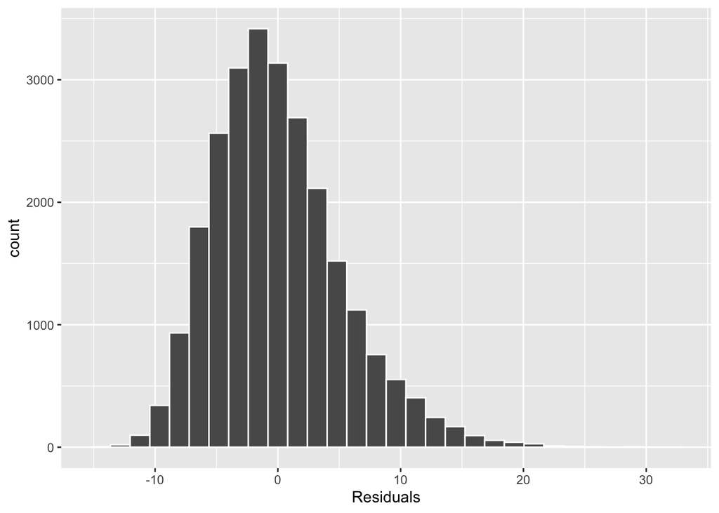

Figure 4: Histogram of residuals

## 3.2 3.2 Differences in the BMI distribution by age, gender, socio-economic status or lifestyle factors.

The next part of our statistical analysis will look at whether there any differences in the BMI distribution by age, gender, socio-economic status or lifestyle factors, this will be carried out using step wise regression with backward selection based on the Akaike information criterion (AIC).

The model we will start with will be the full model with all predictor variables, namely, *AgeGroup,Sex, Employment and Lifestyle*. After performing backward selection on this model we see the results from the R output below. We can see that if we remove *Sex* from the model the AIC will decrease whereas removing any other variable will only increase the AIC. Thus the stepwise regression output suggests that the model without Sex is slightly better according to the AIC. The remaining variables (AgeGroup, Employment, Lifestyle) all appear to contribute to the model since removing any of them would increase the AIC, leading to a reduced model without sex as a predictor variable.

```
Start:  AIC=82516.48
BMI ~ AgeGroup + Sex + Employment + Lifestyle

             Df Sum of Sq    RSS   AIC
- Sex         1      15.7 663693 82515
<none>                    663677 82516
- Lifestyle   3     913.3 664591 82545
- Employment  6    2195.0 665872 82588
- AgeGroup    6   17156.8 680834 83148

Step:  AIC=82515.08
BMI ~ AgeGroup + Employment + Lifestyle

             Df Sum of Sq    RSS   AIC
<none>                    663693 82515
- Lifestyle   3     924.4 664617 82544
- Employment  6    2207.1 665900 82587
- AgeGroup    6   17184.8 680878 83148
```

Table 7: Regression table of reduced model.

| term | estimate | std_error | statistic | p_value | lower_ci | upper_ci |
| --- | --- | --- | --- | --- | --- | --- |
| intercept | 24.71 | 0.34 | 73.40 | 0.00 | 24.05 | 25.37 |
| AgeGroup: 25-34 | 1.18 | 0.16 | 7.54 | 0.00 | 0.87 | 1.48 |
| AgeGroup: 35-44 | 2.50 | 0.15 | 16.43 | 0.00 | 2.20 | 2.79 |
| AgeGroup: 45-54 | 2.77 | 0.15 | 18.24 | 0.00 | 2.47 | 3.07 |
| AgeGroup: 55-64 | 3.28 | 0.16 | 20.68 | 0.00 | 2.97 | 3.59 |
| AgeGroup: 65-74 | 3.20 | 0.19 | 16.56 | 0.00 | 2.82 | 3.58 |
| AgeGroup: 75+ | 2.34 | 0.21 | 10.94 | 0.00 | 1.92 | 2.76 |
| Employment: In full-time education | −0.87 | 0.36 | −2.42 | 0.01 | −1.58 | −0.17 |
| Employment: In paid employment, self-employed or on gov't training | 0.66 | 0.31 | 2.10 | 0.04 | 0.04 | 1.27 |
| Employment: Looking after home/family | 0.47 | 0.34 | 1.39 | 0.16 | −0.19 | 1.13 |
| Employment: Looking for/intending to look for paid work | 0.24 | 0.36 | 0.66 | 0.51 | −0.47 | 0.95 |
| Employment: Perm unable to work | 1.18 | 0.35 | 3.41 | 0.00 | 0.50 | 1.86 |
| Employment: Retired | 0.64 | 0.33 | 1.95 | 0.05 | −0.01 | 1.29 |
| Lifestyle: Just Veg | 0.09 | 0.08 | 1.08 | 0.28 | −0.07 | 0.26 |
| Lifestyle: Just Fruit | 0.60 | 0.11 | 5.68 | 0.00 | 0.39 | 0.81 |
| Lifestyle: None | 0.28 | 0.11 | 2.54 | 0.01 | 0.06 | 0.50 |

Therefore our final model with only significant variables and factors is:

$$\begin{aligned}
\widehat{\text{BMI}} = & \; 24.71 \\
& + 1.18 \cdot \mathbb{1}_{\text{AgeGroup: 25-34}}(x) \\
& + 2.50 \cdot \mathbb{1}_{\text{AgeGroup: 35-44}}(x) \\
& + 2.77 \cdot \mathbb{1}_{\text{AgeGroup: 45-54}}(x) \\
& + 3.28 \cdot \mathbb{1}_{\text{AgeGroup: 55-64}}(x) \\
& + 3.20 \cdot \mathbb{1}_{\text{AgeGroup: 65-74}}(x) \\
& + 2.34 \cdot \mathbb{1}_{\text{AgeGroup: 75+}}(x) \\
& - 0.87 \cdot \mathbb{1}_{\text{Employment: In full-time education}}(x) \\
& + 0.66 \cdot \mathbb{1}_{\text{Employment: In paid employment, self-employed or on gov't training}}(x) \\
& + 1.18 \cdot \mathbb{1}_{\text{Employment: Perm unable to work}}(x) \\
& + 0.60 \cdot \mathbb{1}_{\text{Lifestyle: Just Fruit}}(x) \\
& + 0.28 \cdot \mathbb{1}_{\text{Lifestyle: None}}(x)
\end{aligned}$$

where

- $\mathbb{I}_{\mbox{factor}}(x)$ is an indicator function indicating whether an individual meets the description of this factor.

The goal of our investigation was to look into differences in the distribution of BMI among different demographic, socioeconomic, and lifestyle parameters. The results suggest that BMI rises with age, with each age group beyond the base age category having a greater BMI. Another important component is employment status; students typically have lower BMIs, indicating that lifestyle variables related to full-time schooling may be responsible for lower BMIs. On the other hand, people who are unable to work continuously typically have higher BMIs, which may be linked to a decrease in physical activity or other health problems.

Overall, these insights illustrate the multifaceted nature of factors contributing to BMI variations and underscore the importance of a holistic approach when designing public health initiatives to address overweight and obesity.

### 3.2.1 Assumption Checking

The model fitted assumes that the errors are independent and follow a normal distribution with mean zero and constant variance. The assumption of independence is assumed to already be met. The other assumptions will be assessed below using residuals against fitted values to assess the assumption of mean zero and constant variance as well as a qq-plot and histogram of residuals to asses the assumption of normally distributed residuals.

We can see from the plot of residuals against fitted values in Figure 5 that there appears to be more points above the x axis than below, however since our dataset is very large we can relax the assumption of homoscedasticity. We can also see the histogram of residuals, which appears to be roughly bell shaped, however there does appear to be a slight right skew, but due to the central limit theorem and the size of our dataset we can assume the assumption of the normality of residuals is met.

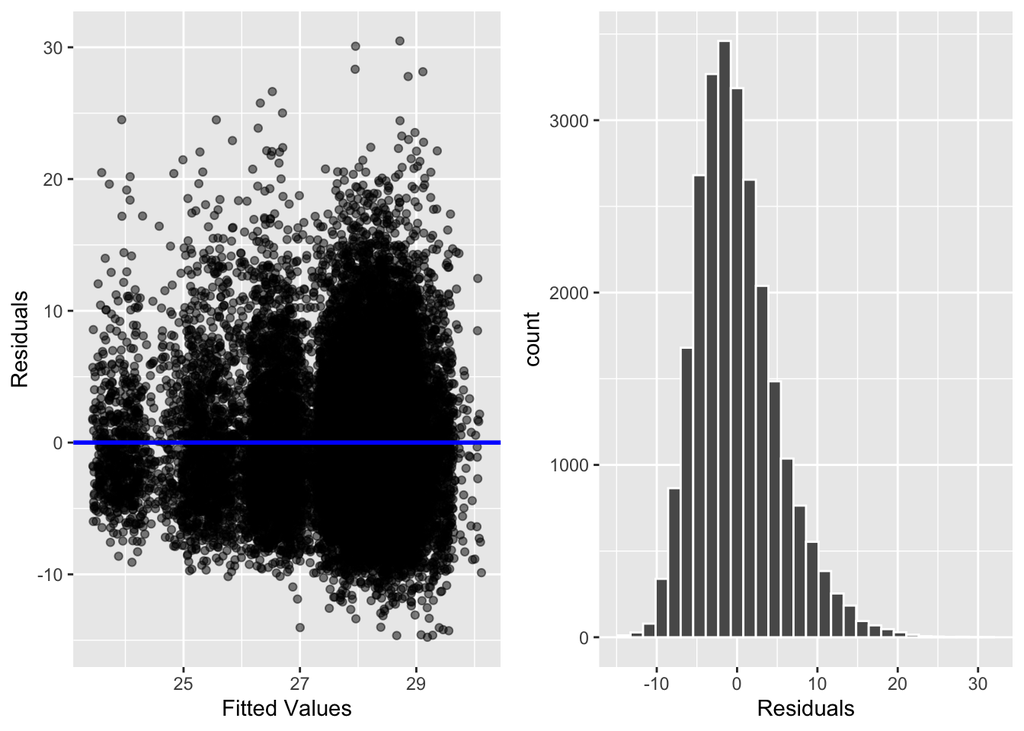

Figure 5: Residuals against fitted values (left) with jitter added to reduce overlap, and histogram of residuals (right)

# 4 Conclusions

By investigating our two main questions of interest with the given data collected by the Scottish Health Survey, we have reached to the conclusion that the body mass index (BMI) in Scotland has not had significant change over the 2008-2012 of the Scottish Health Survey. Furthermore, our analysis indicates that while gender does not significantly impact BMI, age and employment status do. Specifically, we observed that individuals in the 55-64 age bracket had higher BMIs on average. Employment status also had a notable association with BMI; those unable to work due to permanent disability tended to have higher BMI figures, as did retirees, whereas individuals engaged in full-time education had the lowest average BMIs. These findings highlight the importance of considering age and occupation in public health initiatives aimed at managing BMI and suggest avenues for future research to further understand these relationships.